# MACS205 :TD Équations différentielles

Régis Gourdel

Sun Apr 2 23:56:28 2017

```r
library(deSolve)
```

**Question 1**

*a/*

```r
N = function(N0,b,t) { N0 * exp(b*t) }
```

*b/*

```r
N(1, 0.2, 1000)
```

```
## [1] 7.225974e+86
```

**Question 4**

On définit les paramètres pour toute la suite du problème :

```r
parms = c(rs = 0.15,
         Ms = 800,
         ds = 1,
         rc = 0.18,
         Mc = 1200,
         dc = 3)

Nini  = c(Ns = 1000, Nc = 10)
```

Ainsi que la fonction qui donne la dérivée:

```r
gompertz_competition = function(t,N,params){
    with(as.list(c(N,parms)), {
        dNs = rs * N[1] * log(Ms / max(1,N[1] + N[2]))
        dNc = rc * N[2] * log(Mc / max(1,N[1] + N[2]))
        return( list(c(dNs,dNc)) )
    })
}
```

et l’on fait appel à `ode`:

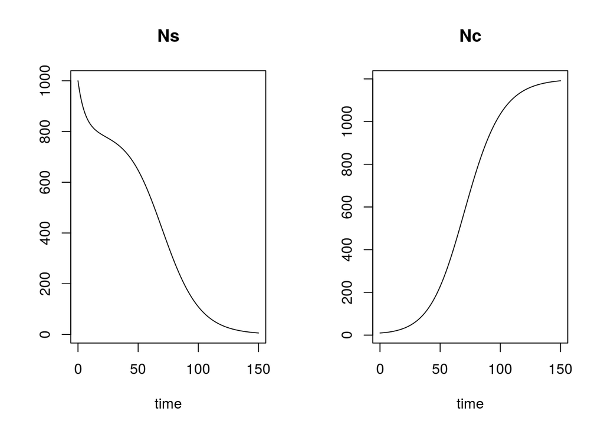

```r
times = seq(0, 150, length.out = 1000)
out = ode(Nini, times, gompertz_competition, pars)
plot(out)
```

**Question 5**

On réalise la fonction `euler` pour résoudre le système différentiel :

```r
euler = function(yini, times, func, pars) {
  n = length(times)
  y1 = c(yini[1])
  y2 = c(yini[2])
  for (i in 2:n) {
    d  = unlist( func(times[i-1], c(y1[i-1], y2[i-1]), pars) )
    dt = times[i] - times[i-1]
    y1 = c(y1, y1[i-1] + dt*d[1])
    y2 = c(y2, y2[i-1] + dt*d[2])
  }
  return( rbind(y1,y2) )
}
```

On teste la fonction avec `gompertz_competition` :

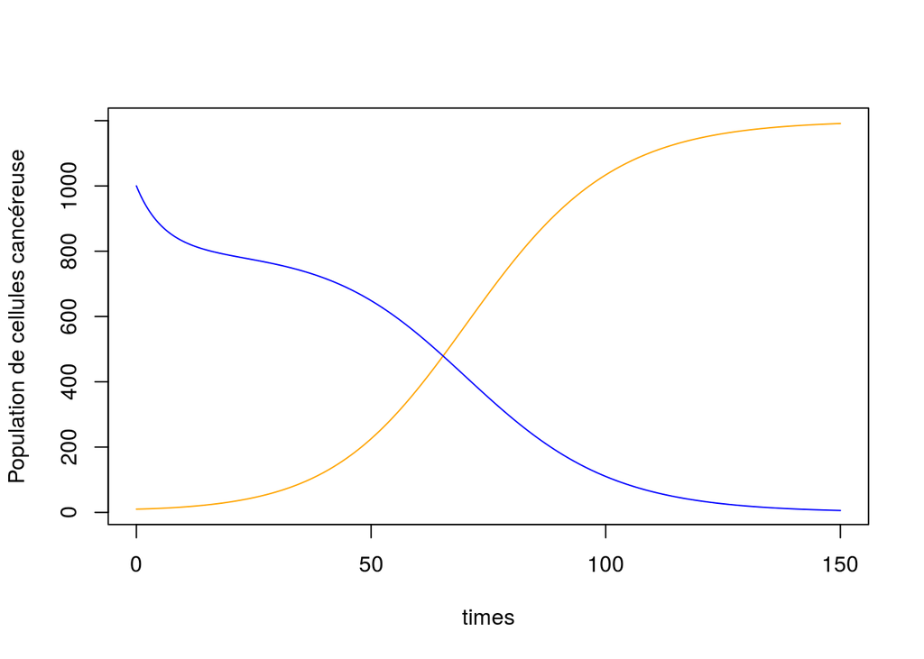

```r
outEuler = euler(c(1000,10), times, gompertz_competition, pars)
NsEuler = outEuler[1,]
NcEuler = outEuler[2,]

plot(times, NcEuler, type = 'l', col = "orange", ylab = "Population de cellules cancéreuse")
lines(times, NsEuler, type = 'l', col = "blue", ylab = "Population de cellules saines")
```

**Question 6**

Avec les paramètres donnés on constate que la population de cellules saines tend à disparaître alors que le nombre de cellules cancéreuses grandit jusqu’à une certaine limite.

**Question 7**

```r
injection = function(t) {
    if ((t >= 30 && t < 31) || (t >= 55 && t < 56) || (t >= 80 && t < 81))
        return(1)
    else
        return(0)
}

gompertz_chimiotherapie = function(t, N, params) {
    with(as.list(c(N,parms)), {
        dNs = rs * N[1] * log(Ms / max(1,N[1] + N[2])) - ds * N[1] * injection(t)
        dNc = rc * N[2] * log(Mc / max(1,N[1] + N[2])) - dc * N[2] * injection(t)
        return( list(c(dNs,dNc)) )
    })
}
```

On crée une fonction pour automatiser le tracer des courbes :

```r
plotChimio = function(func,times) {
    outChimio = func(Nini, times, gompertz_chimiotherapie, pars)
    NsChimio = outChimio[1,]
    NcChimio = outChimio[2,]
    c_range = range(0, NsChimio, NcChimio)
    plot(times, NsChimio, type = 'l', col = "blue", ylim = c_range)
    lines(times, NcChimio, type = 'l', col = "orange")
}
```

On teste alors la modélisation de la chimio en affinant le pas:

La première, avec un pas de 1 dévie fortement vers $-\infty$ pour les cellules cancéreuses :

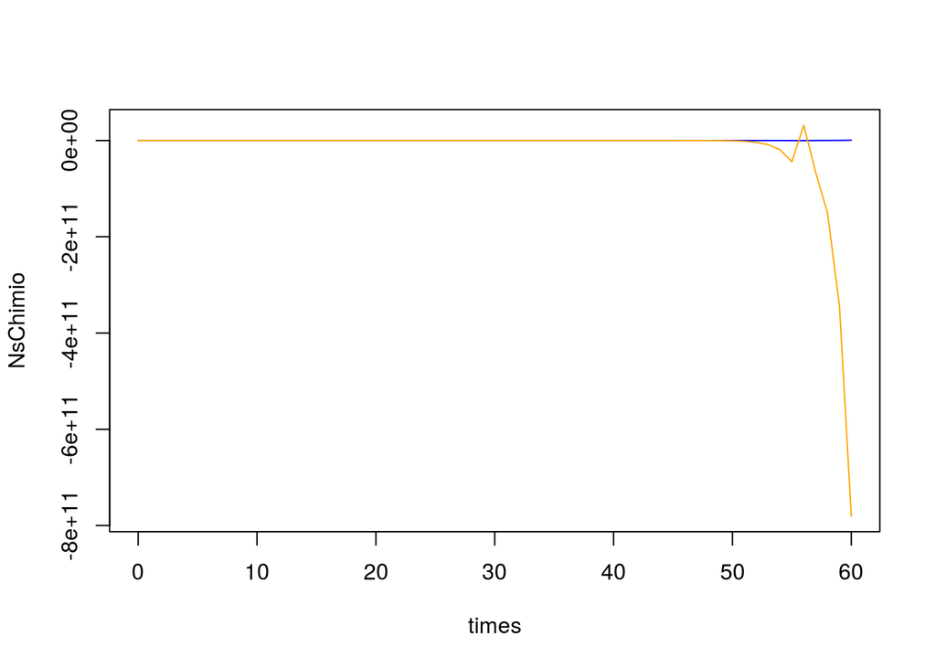

```r
plotChimio(euler, seq(0, 60, by = 1))
```

La seconde, avec un pas de 0.5 donne un résultat qui n’est pas correct, et dévie également ensuite :

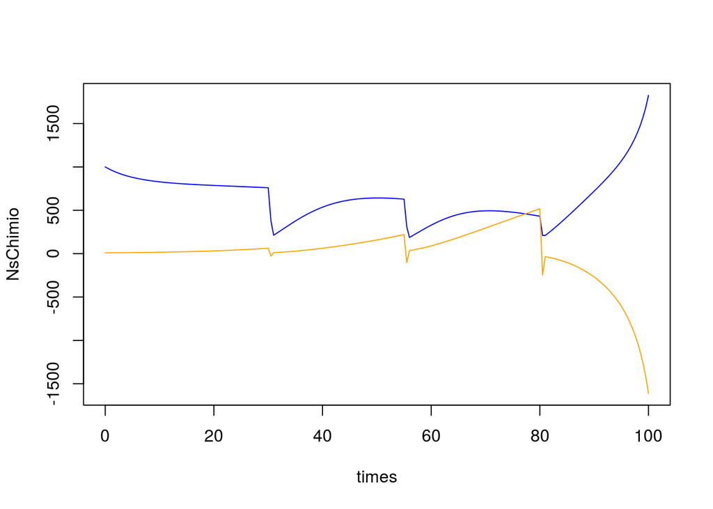

```r
plotChimio(euler, seq(0, 100, by = 0.5))
```

Les deux suivantes fournissent un tracé plus cohérent :

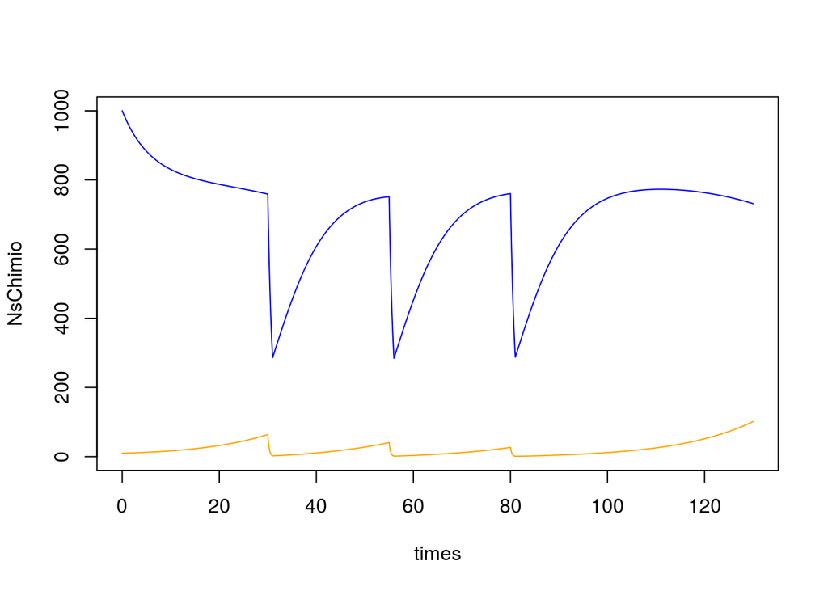

```r
plotChimio(euler, seq(0, 130, by = 0.1))
```

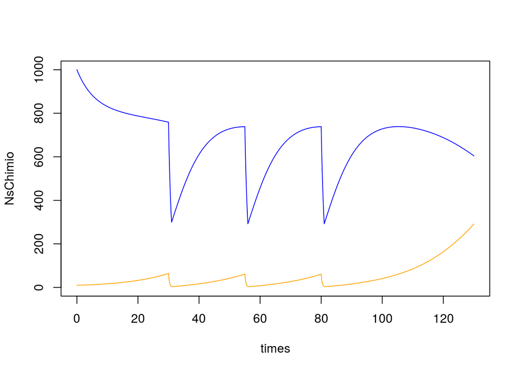

```r
plotChimio(euler, seq(0, 130, by = 0.01))
```

Un pas de 0.001 est trop petit pour être exécuté dans un temps raisonnable donc nous nous contentons de ceux plus grands.

On reproduit maintenant cela avec la fonction `ode` :

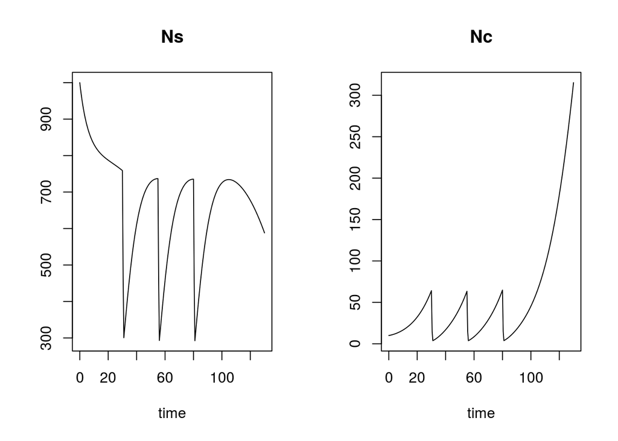

```r
outR2 = ode(Nini, times = seq(0, 130, by = 0.5), gompertz_chimiotherapie, pars)
plot(outR2)
```

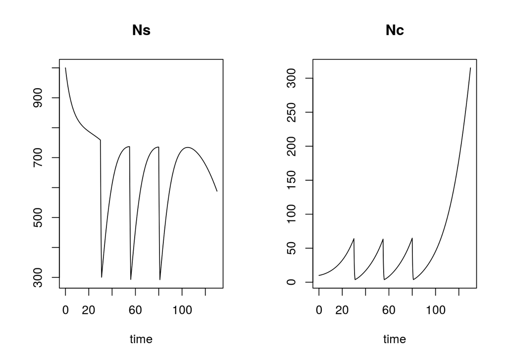

```r
outR3 = ode(Nini, times = seq(0, 130, by = 0.1), gompertz_chimiotherapie, pars)
plot(outR3)
```

On constate que les résultats sont similaires.

**Question 8**

On code une fonction pour appliquer la méthode de Runge-Kutta avec $q = 4$ :

```r
RK4 = function(yini, times, func, pars) {
    n = length(times)
    y1 = c(yini[1])
    y2 = c(yini[2])
    a2 = 1/2; a3 = 1/2; a4 = 1
    b1 = 1/6; b2 = 2/6; b3 = 3/6; b4 = 4/4
    for (i in 2:n) {
        y = c(y1[i-1], y2[i-1])
        h   = times[i] - times[i-1]
        k1  = unlist( func(times[i-1], y, pars) )
        k2  = unlist( func(times[i-1] + a2*h , y + a2*k1*h, pars) )
        k3  = unlist( func(times[i-1] + a3*h , y + a3*k2*h, pars) )
        k4  = unlist( func(times[i-1] + a4*h , y + a4*k3*h, pars) )
        phi = b1*k1 + b2*k2 + b3*k3 + b4*k4
        y1  = c(y1, y1[i-1] + h * phi[1])
        y2  = c(y2, y2[i-1] + h * phi[2])
    }
    return( rbind(y1,y2) )
}
```

et l’on teste notre fonction pour les pas 0.5, 0.1 et 0.01.

Le premier n’est pas probant, et dévie rapidement vers $-\infty$ pour les cellules cancéreuses sur un intervalle plus grand :

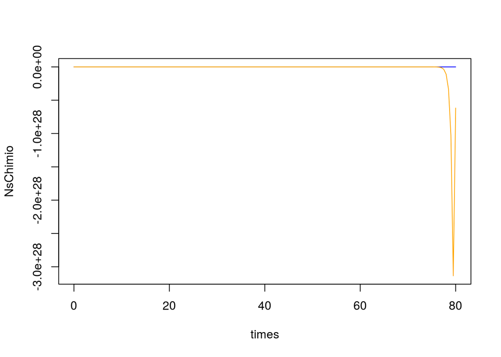

```r
plotChimio(RK4, seq(0, 80, by = 0.5))
```

Les deux suivants fournissent une solution assez bonne :

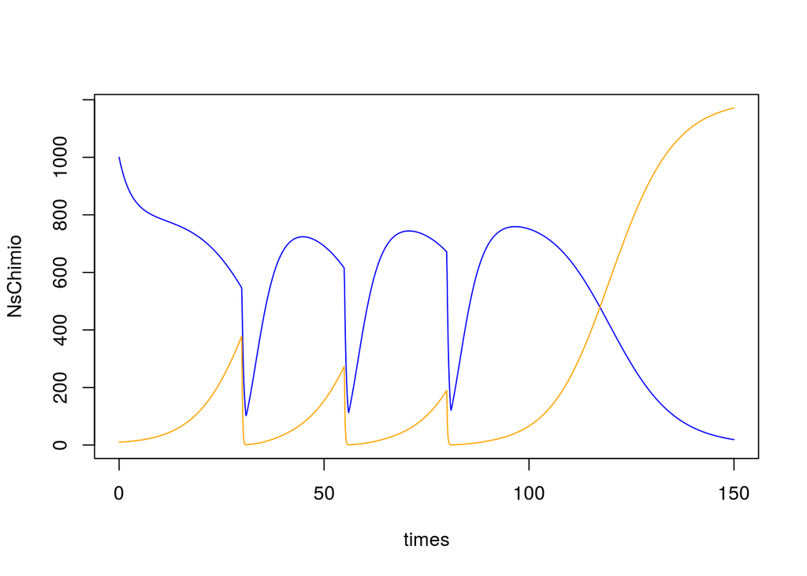

```r
plotChimio(RK4, seq(0, 150, by = 0.1))
```

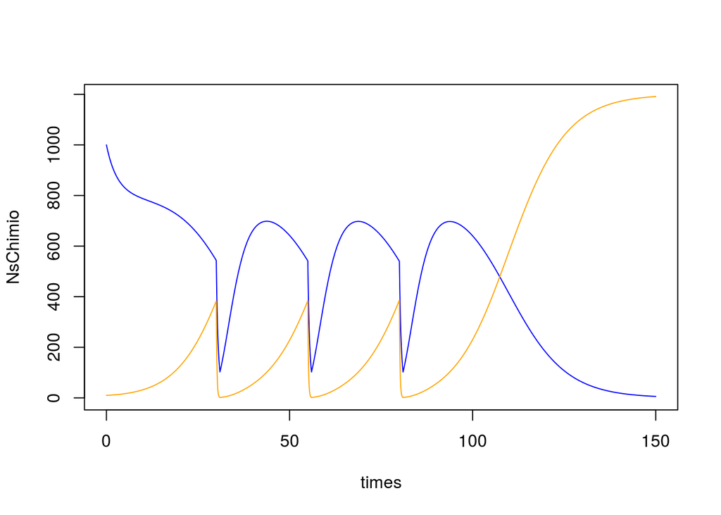

```r
plotChimio(RK4, seq(0, 150, by = 0.01))
```

**Question 9**

On constate que c’est au moment des injections que se produisent les changements les plus rapides. On peut donc définir un maillage temporel plus serré sur ces moments ci.

Le pas de base adopté est 0.5, qui ne fonctionne pas normalement, et l’on divise ce pas par 5 autour des moments d’injection.

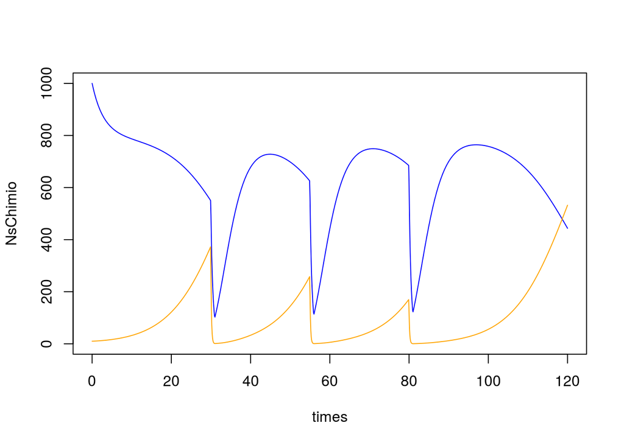

```r
pas = 0.5
t1  = seq(0, 29, by = pas)
t2  = seq(29 + pas, 32, by = pas/5)
t3  = seq(32 + pas, 54, by = pas)
t4  = seq(54 + pas, 57, by = pas/5)
t5  = seq(57 + pas, 79, by = pas)
t6  = seq(79 + pas, 82, by = pas/5)
t7  = seq(82 + pas, 120, by = pas)
times = c(t1,t2,t3,t4,t5,t6,t7)

plotChimio(RK4, times)
```

On constate donc que l’on trouve un résultat proche de celui que nous avions pour un pas de 0.1, alors que le nombre de points a été ici nettement réduit, et le maillage temporel n’est affiné qu’en quelques endroits.